# Estimate of asymptomatic cases of COVID-19

## The Idea

Asymptomatic cases can transmit the disease while not being detected and are assumed to have heavily contributed to the spread of SARS-CoV-2. Several studies have attempted to estimate the asymptomatic fraction of people carrying the virus and given very different results. Determining how many people unwittingly spread the disease is essential for planning intervention strategies, for both the current outbreak and possible recurrences in the future. On the basis of data from the early outbreak in China and especially Wuhan, [Li et al.](https://science.sciencemag.org/content/early/2020/03/24/science.abb3221). used a migration based SEIR model to infer a shocking 86% of undocumented cases in this period. However, a clear separation of undocumented and asyomptotic cases was left out, which we plan to include in our estimations. We are going to follow this framework, using transit data (airline data from the bureau of transportation and commuter data from the census bureau) for the US and other countries to estimate the fraction of asymptomatic carriers and how the spread of disease is impacted by these invisible carriers.

## The Model

[Li et al.](https://science.sciencemag.org/content/early/2020/03/24/science.abb3221) estimated that during the early outbreak of SARS-CoV-2 in China and especially Wuhan, from January 10th to January 23rd, there were 86% of asymptomatic and not documented cases. They used a metapopulation SEIR model which assumes spreading within a subpopulation described by a SEIR model with a fraction of $\alpha$ infected which are symptomatic, $I_i^s$, and have a transmissibility of $\beta$, and a fraction of (1-$\alpha$) asymptomatic infected, $I_i^a$, with reduced transmissibility $\mu\beta$. Mobility is given on a day by day basis in the matrix $M$, exposed individuals $E$ become infectious after a latency period $Z$ and recover after a period $D$.

\begin{align} \frac{d}{dt}S_i =& -\beta \frac{S_i}{N_i} \left( \alpha I_i^s +(1-\alpha)\mu I_i^a\right) + \theta\sum_j \frac{M_{ij} S_j}{N_j-I_j^s} - \theta\sum_j \frac{M_{ji} S_i}{N_i-I_i^s} \\ \frac{d}{dt}E_i =& \beta \frac{S_i}{N_i} \left( \alpha I_i^s +(1-\alpha)\mu I_i^a\right) + \theta\sum_j \frac{M_{ij} E_j}{N_j-I_j^s} - \theta\sum_j \frac{M_{ji} E_i}{N_i-I_i^s} - \frac{E_i}{Z}\\ \frac{d}{dt}I_i^s =&\alpha \frac{E_i}{Z} - \frac{I_i^s}{D}\\ \frac{d}{dt}I_i^a =&(1-\alpha) \frac{E_i}{Z} - \frac{I_i^a}{D}+ \theta\sum_j \frac{M_{ij} I_j^a}{N_j-I_j^s} - \theta\sum_j \frac{M_{ji} I_j^a}{N_i-I_i^s}\\ N_i =& N_i + \sum_j M_{ji} - \sum_j M_{ij} \end{align}

For details on the model check the reference mentioned above. A critical aspect of the model is that every reported case is symptomatic, and has a higher transmission rate than undocumented cases, which are assumed to be asymptomatic. One of the results of the papers is that following the travel restrictions in China, there was a substantial increase in the fraction of reported cases, which would coincide with a higher fraction of symptomatic cases. We think there should be a separation of symptomatic and reported cases in the model, which we plan to include in our analysis.

## Redoing the analysis

First we tried to repeat the analysis that the authors performed in the paper, and use simulations on the basis the inferred parameters to confirm the estimation. Therefore we wrote a python version of their EAKF inference, which is able to retrieve the same parameters. We were able to reproduce both the estimated parameters and the simulation results from the paper, as shown in the figure below.

## Extending the model to new data sets

The goal of our effort is to apply an improved model to other data sets. We are gathering about domestic air transportation from the [Bureau of Transportation](https://www.transtats.bts.gov/Tables.asp?DB_ID=125&DB_Name=Airline%20Origin%20and%20Destination%20Survey%20%28DB1B%29&DB_Short_Name=Origin%20and%20Destination%20Survey), cross-county transit data from the [census bureau](https://www.census.gov/topics/employment/commuting.html) and data of infections from the [New York Times Github repository](https://github.com/nytimes/covid-19-data). We plan to extend the data sets to Europe as well.

## Figures

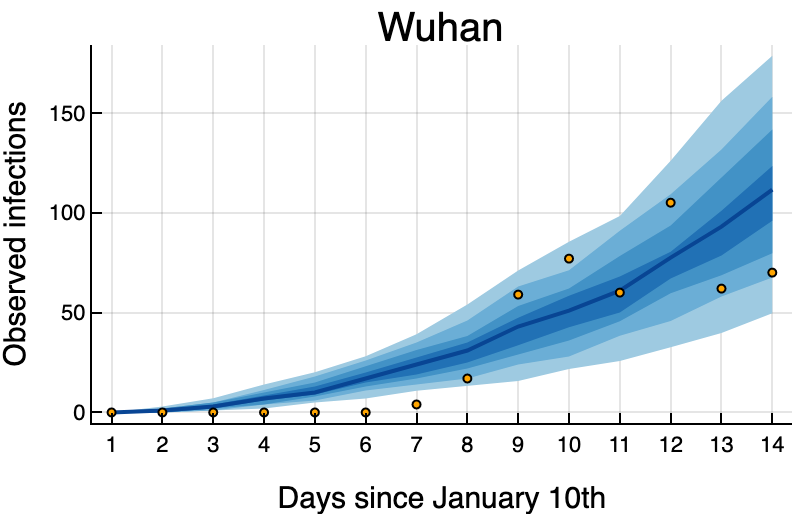

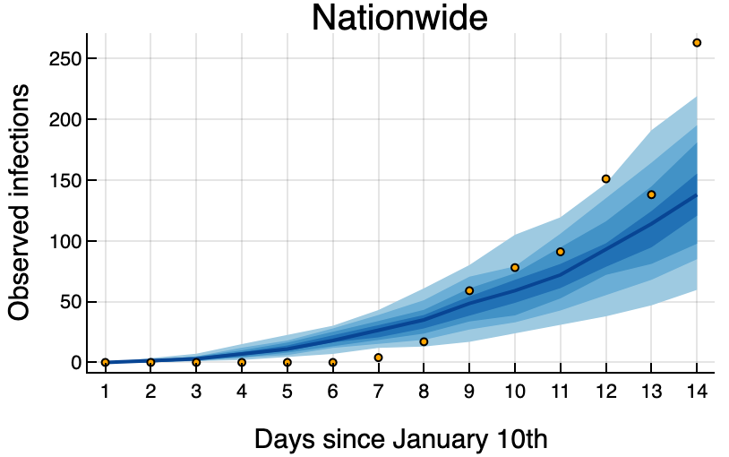

Figure 1: Daily observed new cases in Wuhan, China (top) and all of China (bottom). The data is shown in orange, and simulation results in blue shades, showing regions which contain 20 percent(darkest blue) and up to 80 percent of the results.

### Contributers

Tom Röschinger, Rachel Banks